## Black Oystercatchers (*Haematopus bachmani*)

### Map of observations

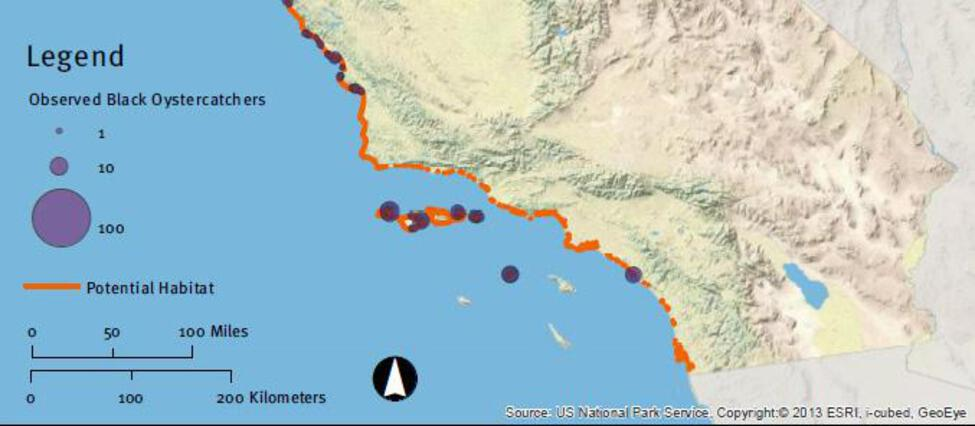

**Figure App.F.13.4.**. A map showing a 2011 survey of suitable black oystercatcher habitat (orange) along the coast of the Channel Islands and Southern to Central California.

**Click for Details**

In 2011, approximately 20 percent of the suitable habitat (orange) for black oystercatchers *Haematopus bachmani* was surveyed. A total of 176 adult or sub-adult black oystercatchers were detected at the five islands in Channel Islands National Marine Sanctuary. Density at different locations is shown by the diameter of the purple circles. The northern Channel Islands population was conservatively estimated to be between 779–854, which is 14 to 16 percent of the estimated total population in California. Figure: Modified from Weinstein et al. 2014

### Abundance by site (CINP data)

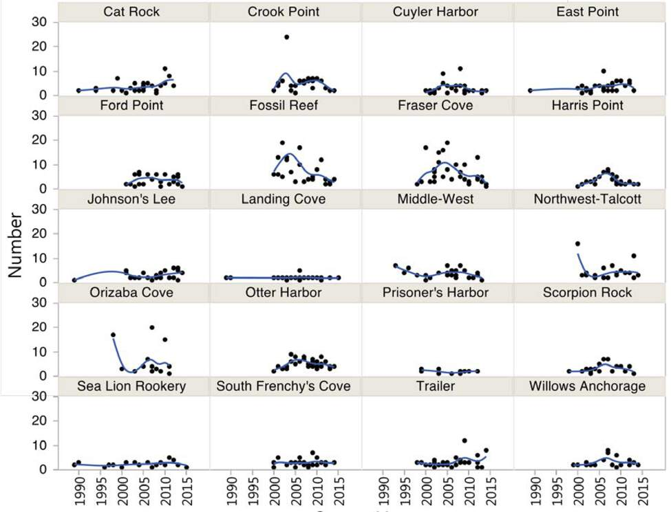

**Figure App.F.13.5.**. A figure showing the number of black oystercatchers observed at 20 sites across the Channel Islands from 1990 - 2015.

**Click for Details**

Number of black oystercatchers *Haematopus bachmani* observed during surveys at 20 rocky shore sites by Channel Islands National Park. Data are collected opportunistically. Curved lines represent statistically smoothed means. Figure: [Channel Islands National Park](https://www.nps.gov/chis/index.htm)

### Abundance on Santa Cruz Island (Audubon data)

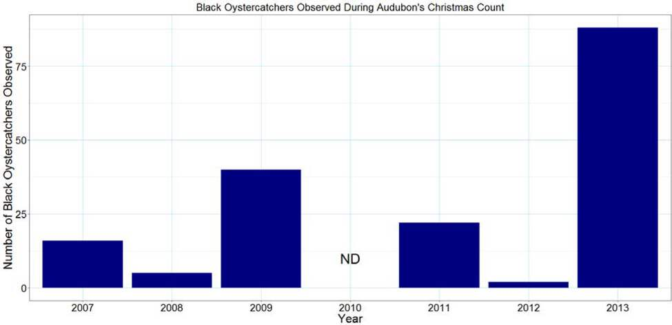

**Figure App.F.13.6.**. A figure showing the number of black oystercatchers observed on Santa Cruz Island during the Audubon Christmas Bird Count from 2007 - 2013.

**Click for Details**

Number of black oystercatchers *Haematopus bachmani* observed at Santa Cruz Island during the Audubon Christmas Bird Count from 2007 to 2013.; no data were available for 2010. Data source: Audubon Christmas Bird Count; Figure: [R. Freedman/NOAA](https://channelislands.noaa.gov/contact/freedman.html)